# Welcome to CMM202 - Programming for Business Analytics!

## Before we start...

1. Attendance (Attendr)
2. Moodle
   1. Resources (Trello)
   2. Reinforcement courses (Datacamp)
   3. Assessment times (Ask me)

## Assesment Information

Two courseworks:

```
- P1: Individual (26th February)
- P2: Group (26th March)
```

After today's lecture, we will have a coursework clarification session for part 1

# "Intro" to Jupyter Notebook

You may all be familiar with Jupyter Notebook by now as you used it extensively in CMM201

This session will further help you understand how to better work with it for the purpose of this module!

### Presenting your Jupyter Notebook

This presentation was done using Jupyter Notebook!

Jupyter Notebooks have plenty of `nbextension` which can be installed just as any package in Python

For instance, this one is called `rise`, and it is installed using the following command:

```
- pip install RISE
```

```python
!pip install RISE # we use ! to execute prompt commands in cells
```

To install this extension, you can run the following command:

```
- jupyter nbextension install rise --py --sys-prefix
```

To enable this extension, you can run the following command:

```
- jupyter nbextension enable --py rise --sys-prefix
```

Moreover, you can always check your `nbextensions` in the "main menu"

Don't forget that, for `rise` to work, you have to enable the slide option in your notebook

Every time you start a project, go to View -> Cell Toolbar -> Slideshow to enable the different slide options:

```
- Slide
- Sub-slide
- Fragment
- Notes
```

#### Migrating your RISE presentation to other formats

Obviously, the main drawback of `rise` is the portability

That's why Jupyter offers a variety of formats to convert your `.ipynb` to:

```
- html: File -> Download as -> html
- html slides: File -> Download as -> slides (slides.html)
- pdf slides: Change the last bit of the slides.html to `?print-pdf` and print
- pdf (via LaTeX): File -> Download as -> latex (.tex) or pdf (.tex)
```

I will demo how to convert to each using this notebook!

I recommend you to check [this post](https://www.markroepke.me/posts/2019/06/05/tips-for-slideshows-in-jupyter.html) for more tips to do neat presentations!

### Spell Check

A necessary feature for *everyone*!

```
- pip install jupyter_contrib_nbextensions
- jupyter contrib nbextension install --user
- jupyter nbextension enable spellchecker/main
```

### Keyboard Shortcuts

Having an idea of the shortcuts will help you produce notebooks faster!

Check your shortcuts in Help -> Keyboard Shortcuts

For instance, you can press "B" and add a cell below (instead of going to the menu!

### Markdown

Since you will be presenting your coursework part 2 as a Jupyter Notebook, I recommend you to have a very good idea of how to use the Markdown

You can check [this post](https://medium.com/analytics-vidhya/the-ultimate-markdown-guide-for-jupyter-notebook-d5e5abf728fd) for the "ultimate" guide on how to use markdown

Still, I will show you one of the key aspects that I am interested i.e. including images and videos

## Loading images/videos into a Jupyter Notebook

Images from your local drive (using a Markdown cell):

1. Store the image **in the same directory as the notebook**
2. Use "!", then put a text inside squared brackets "[]" for reference, and parenthesis "()" for the file name
   - ![Fig 1.](test.jpg)

[figure not shown]

If you prefer, you can create a subdirectory for all of your images:

```
- \![Fig 2.]\(figs/test.jpg)
```

[figure not shown]

Inserting an image online (make sure you have access always)

- ![Fig 3.](web address)

[figure not shown]

Loading an image AS DATA, you can use packages such as `OpenCV` or `Pillow`

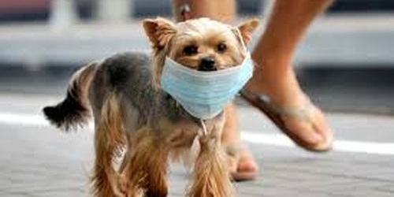

```python
from PIL import Image
im = Image.open("test.jpg")
im
```

```python
# The variable im contains the pixels of the image
im.size
```

```
(500, 250)
```

Inserting a YouTube Video:

```
1. Go to YouTube
2. Under "Share" select embed
3. You will get an html code, copy it inside the following Python code
```

```
from IPython.display import HTML
HTML('embed html code here')
```

```python
from IPython.display import HTML
HTML('<iframe width="560" height="315" src="https://www.youtube.com/embed/r-uOLxNrNk8" frameborder="0" allow="accelerometer; autoplay; clipboard-write; encrypted-media; gyroscope; picture-in-picture" allowfullscreen></iframe>')
```

[video not shown]

## Loading data into a Jupyter Notebook

Just as we loaded the dog image as data before, you are perfectly familiar with the fact that we can load data from different data types (.csv, .tsv, .txt, .xlsx) to our notebooks!

The easiest way to do so is with `Pandas`

```python
import pandas as pd
data = pd.read_csv('data.csv')
data
```

|  | Col 1 | Col 2 | Col 3 |
| --- | --- | --- | --- |
| 0 | Nick | 21 | 1.85 |
| 1 | Chris | 29 | 1.79 |
| 2 | Tim | 28 | 1.75 |
| 3 | Ron | 34 | 1.81 |
| 4 | Monica | 35 | 1.69 |
| 5 | Cassandra | 21 | 1.66 |

Commands such as `read_csv` can also take a web address as an input, and load images from online repos!

For instance, if `data.csv` is in my dropbox, I can copy the dropbox link, change `dl=0` for `raw=1` and load the file

```python
data_dropbox = pd.read_csv('https://www.dropbox.com/s/987e0rfu0ufneqo/data.csv?raw=1')
data_dropbox
```

|  | Col 1 | Col 2 | Col 3 |
| --- | --- | --- | --- |
| 0 | Nick | 21 | 1.85 |
| 1 | Chris | 29 | 1.79 |
| 2 | Tim | 28 | 1.75 |
| 3 | Ron | 34 | 1.81 |
| 4 | Monica | 35 | 1.69 |
| 5 | Cassandra | 21 | 1.66 |

Another option is [GitHub](https://github.com/carlosfmorenog/CMM202), were you can upload files, get the "raw" version and import it

```python
data_git = pd.read_csv('https://raw.githubusercontent.com/carlosfmorenog/CMM202/master/CMM202_Week%20_1/data.csv')
data_git
```

|  | Col 1 | Col 2 | Col 3 |
| --- | --- | --- | --- |
| 0 | Nick | 21 | 1.85 |
| 1 | Chris | 29 | 1.79 |
| 2 | Tim | 28 | 1.75 |
| 3 | Ron | 34 | 1.81 |
| 4 | Monica | 35 | 1.69 |
| 5 | Cassandra | 21 | 1.66 |

If the current situation allows it, in March we will have a face-to-face workshop on how to use GitHub

## Online Jupyter Notebooks

### Google Colab

https://colab.research.google.com/drive/1aDbBPl2p-dSdQznAH7DGWb0jxyeFLytp?usp=sharing

### Kaggle

https://www.kaggle.com/carlosmorenogarcia/cmm202-week1-lec

### Github

https://github.com/carlosfmorenog/CMM202/blob/master/Week%20_1/CMM202_W1_Lec.ipynb

# "Lab 1": Coursework Clarification